# Lecture 9: Exact Inference Examples

October 4, 2016

## Lecture 8 Main Points Once Again

- Belief propagation (Pearl 1988; Lauritzen and Spiegelhalter, 1988, JRSS-B)
- Computes the exact marginal probability for each node in a factor graph that has a tree structure
- Reduced computational complexity. For example, in a **chain graph** with \(d\) discrete variables (\(k\) states), from exponential (\(\mathcal{O}(k^d)\)) to linear in the number of nodes and quardratic in the number of states (\(\mathcal{O}(dk^2)\), why?)
- No reduction in computational complexity of exact inference if the graph is fully connected: we are forced to work with the full joint distribution
- Share computations efficiently when many marginal probabilities are required (example on whiteboard)
- In belief propagation for finding the marginal probability at every node, a *message* is a re-usable partial sum for the marginalization calculations.

## Numerical Example of Belief Propagation (Freeman and Torralba)

- Example: tree-structured **undirected graph** with pairwise potentials
- Binary variables \(x_j\), \(j=1,2,3\) (unobserved), and \(y_2=0\) (observed).
- Calculate \(p(x_j=0), j=1,2,3\), using messages between nodes (whiteboard)

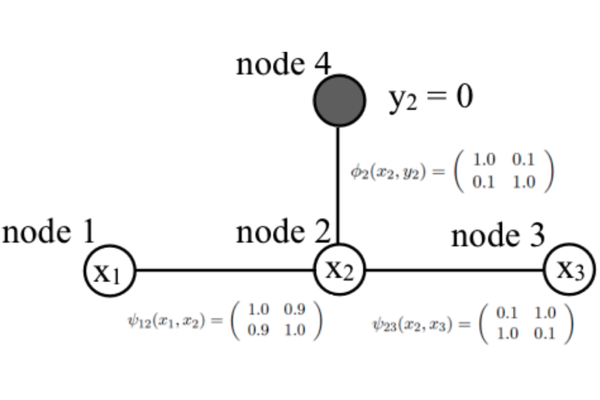

## Factor Graphs as a Tool to Organize Messages

*Remark*:

- Any factor graph could be transformed to an undirected graph with pairwise potentials (Yedidia et al. 2003). The previous example demonstrates a general message-passing strategy on undirected graphs with pairwise potentials.
- Any undirected graphs or directed acyclic graphs can be transformed to factor graphs

## Notations

- \(X\): single variable node; \(x\): an instance of \(X\)
- \(\mathbf{X}\): a vector of variable nodes, e.g., \(\mathbf{X}=(X_1,X_2,X_3)'\); \(\mathbf{x}\) (e.g., \(\mathbf{x}=(x_1,x_2,x_3)'\)): an instance of the random vector \(\mathbf{X}\)
- \(f_C\): a factor/potential in the factorization of the joint distribution: \[p(\mathbf{X}=\mathbf{x})\propto \prod_{C: \text{cliques in an undirected graph $\mathcal{H}$}}f_C(\mathbf{X}_C),\] where a clique \(C\) collects the relevant nodes, say, \(C=\{2,3\}\) and \(\mathbf{X}_C=(X_2,X_3)\) denotes the vector of variables nodes involved in Clique \(C\).
- \(\psi_C\): same as \(f_C\) (used interchangeably in the class)
- \(N(X)\) or \(N(f)\): the neighbor of a variable node or a factor node.

## Sum-Product Algorithm for Factor Trees

The marginal probability \(p(X_i=x_i)=\prod_{f_C\in N(X_i)} m_{f_C\rightarrow X_i}(x_i)\). Choose a variable node as the root (\(X_R\)), then starting from the leaves:

1. If \(f_C\) is a leaf node, then \(m_{f_C\rightarrow X}(x_C)=f_C(x_C)\)
2. If \(X\) is a leaf node, then \(m_{X\rightarrow f_C}(x)=1\)
3. The message sent from a non-leaf factor node \(f_C\) to a variable node \(X_i\) is \[m_{f_C\rightarrow X_i}(x_i)=\sum_{x_{N(f_C)-X_i}}f_C(\mathbf{x}_C)\prod_{x': X'\in {N(f_C)-X_i}} m_{X'\rightarrow f_C}(x')\]
4. The message sent from a non-leaf variable node \(X_i\) to a factor node \(f_C\) is: \[m_{X_i\rightarrow f_C}(x_i) =\prod_{f_{C'} \in N(X_i)-f_C} m_{f_{C'}\rightarrow X_i}(x_i)\]

## Remarks: Sum-Product Algorithm

- "A factor collects messages sent to its arms (except the destination arm), bundles them with its direct interaction with the destination variable node, and collapses (integrates over) the arms (except the destination arm)."
- "A variable node bundles (mutiplies) the incoming messages and sends it to the destination factor node"
- In Step 2, a leaf variable node has no extra information to bundle, just equally weight all \(X=x\) (recall that messages form a vector of dimension \(|X|\), each corresponding to a value of \(x\))
- In Step 4, when a variable node has only two factor neighbors, the rule means: "\(X_i\), please just pass the message from factor \(f_{C'}\) to \(f_{C}\), do nothing else!"
- In Step 3, to find the messages from a factor \(f_C\) to \(X_i\), we integrate all the uncertainties/information about variables other than \(X_i\) but pertaining to \(f_C\). We multiply \(f_C\) by other messages sent to its neighboring nodes (except \(X_i\))

## Example: Sum-Product Algorithm

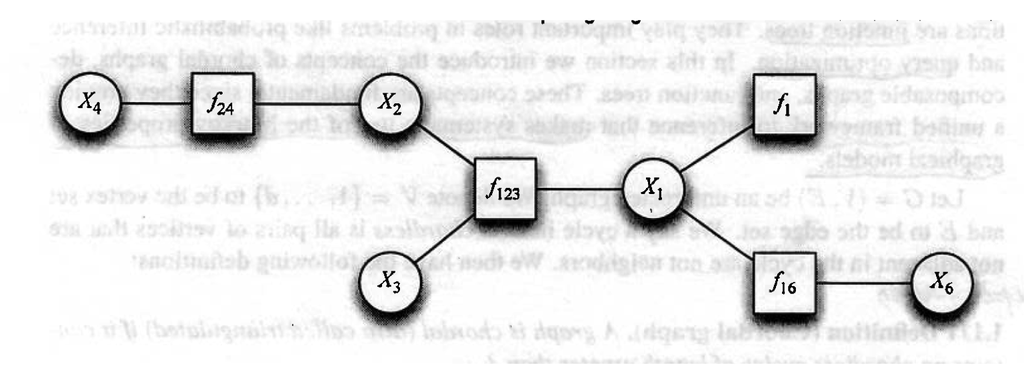

- Calculate the marginal distribution \(p(x_1)\) using the 4 rules in the previous slide \[p(x_1)=\sum_{x_2}\cdots\sum_{x_6}p(\mathbf{x})\]
- Verify that the result of the algorithm is equivalent to a naive marginalization

## Predicting hot or cold days from ice creams ([Jason Eisner, 2002](https://www.cs.jhu.edu/~jason/papers/eisner.tnlp02.pdf))

What's the **weather sequence** with the highest joint probability, given Jason ate 3, 1, and 3 ice creams for the past three days?

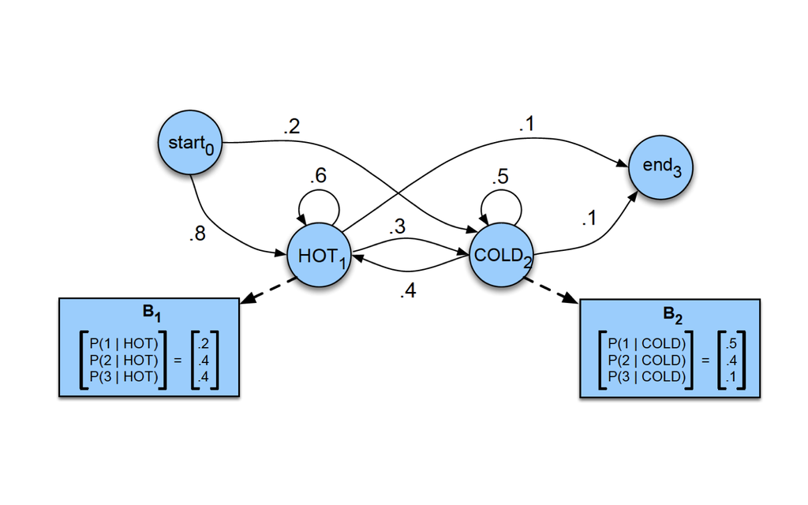

## Max-Sum Algorithm: Highest Joint Probabilities

Choose a variable node as the root (\(X_R\)), then starting from the leaves:

1. If a variable node \(X_i\) is a leaf node: \(m_{X_i\rightarrow f_C}(x_i)=0\)
2. If a factor node \(f_C\) is a leaf node: \(m_{f_C\rightarrow X_i}(x_i)=\log f_C(x_C)\)
3. The message sent from a non-leaf factor node \(f_C\) to a variable node \(X_i\): \[m_{f_C\rightarrow X_i}(x_i) = \max_{\mathbf{x}_{N(f_C)-X_i}}\left[\log f_C(\mathbf{x}_C)+\sum_{x': X' \in N(f_C)-X_i}m_{X'\rightarrow f_C}(x')\right]\]
4. The message sent from a non-leaf variable \(X_i\) to a factor node \(f_C\): \[m_{X_i\rightarrow f_C}(x_i)=\sum_{f_{C'}\in N(X_i)-f_C}m_{f_{C'}\rightarrow X_i}(x_i)\]

## Max-Sum Algorithm: Highest Joint Probabilities (continued)

- Maximize the combined messages from all the neighboring factors: \(\max_{\mathbf{x}} p(\mathbf{x})=\max_{x_R}\sum_{f_C \in N(X_R)}m_{f_C\rightarrow X_R}(x_R)\)
- The value of the root node maximizing the joint probability is \(x^{\max}_R=\arg \max_{x_R}\sum_{f_C \in N(X_R)}m_{f_C\rightarrow X_R}(x_R)\)
- What are the maximizing values for nodes other than \(X_R\)?
  - Q: Can we send messages from the root back to the leaves, and calculate the maximizing value at each variable node?
  - A: Problematic. If \(\mathbf{x}^*\) and \(\mathbf{x}^\dagger\) are two maximizers that differ at the \(i\)th and \(i'\)th dimension, one would obtain two sets: \(x_i^{\max}= \{x_i^*,x_i^{\dagger}\}\) and \(x_{i'}^{\max} = \{x_{i'}^*,x_{i'}^{\dagger}\}\), but without knowing how to match a value in \(x^{\max}_i\) with a value in \(x^{\max}_{i'}\) that together are part of, say, \(\mathbf{x}^*\).

## Back-tracking for finding the configurations with the highest joint probability

- Obtain the exact maximizing configuration for the variables provided the factor graph is a tree
- In Step 3, when a message is sent from a factor \(f_C\) to a variable node \(X_i\), we performed a maximization over all other variables \(\mathbf{X}_C-X_i\), say \((X_{i1},\ldots,X_{iM})\). Specifically, for each value of \(X_i=x_i\), the maximizing vector values for \(\mathbf{X}_C-X_i\) are: \((x_{i1},\ldots,x_{iM})\)
- Keep a record of this maximizing vector
- Having found \(x_R^{\max}\) for the root node, we then use the corresponding stored values \((x_{R1},\ldots,x_{RM})\) to assign as the maximizing states \((x_{R1}^{\max},\ldots,x_{RM}^{\max})\)
- Repeat until one reaches the leaf nodes again

## Self-Evaluation Problem

- Find the most likely **weather sequence** for each of the observation sequences
  - 331121133
  - 111113333

## Comment

- **Next Lecture**:
  - Message passing schedule; Loopy belief propagation
  - Junction tree algorithm (exact for arbitrary graphs; a purely graphical way to precisely and efficiently organize computations)
  - Motivate approximate inference
- **Required reading**:
  - Section 8.4. Bishop, CM. Pattern Recognition and Machine Learning.
- **Optional enjoyment**:
  - [Jason Eisner, 2002](https://www.cs.jhu.edu/~jason/papers/eisner.tnlp02.pdf)